# ocs-rural-and-urban-obesity

###Data Import

First let’s dowload the data so we can take a look at the original data:

```r
library(XML)
library(here)
url <- "https://static-content.springer.com/esm/art%3A10.1038%2Fs41586-019-1171-x/MediaObjects/41586_2019_1171_MOESM1_ESM.pdf"

download.file(url, "paper_supplement.pdf")
```

Now that we have the obesity pdf, we will read it in to R using the pdftools package

```r
library(pdftools)


pdf_obesity<-pdf_text(here("paper_supplement.pdf"))# PDF error: Expected the optional content group list, but wasn't able to find it, or it isn't an Array - errors like this can be common with PDFs... we can take a look at the data to see if it still looks as expected
```

```
## PDF error: Expected the optional content group list, but wasn't able to find it, or it isn't an Array
```

Let’s take a look at the data- the str() function helps us to look at the structure of R objects.

```r
str(pdf_obesity)
```

```
##  chr [1:63] "Letter                                                                                https://doi.org/10.1038/s"| __truncated__ ...
```

We can see that we have 63 elements that are character strings. You may also notice that the orginal PDF has 63 pages. Let’s take a look at some of these elements.

```r
pdf_obesity[1] # this looks like the first page
```

```
## [1] "Letter                                                                                https://doi.org/10.1038/s41586-019-1171-x\nRising rural body-mass index is the main driver of\nthe global obesity epidemic in adults\nNCD Risk Factor Collaboration (NCD-RisC)*\n*A list of authors and their …
```

```r
pdf_obesity[2] # this looks like the second page
```

```
## [1] "Supplementary Information. Statistical model for estimating BMI trends by rural and urban\nplace of residence.\n                                          1\n"
```

```r
pdf_obesity[3] # this looks like the third page
```

```
## [1] "Statistical model\nThe Bayesian hierarchical model used for estimating mean body-mass index (BMI) trends by\nrural and urban place of residence was summarised in Methods. Here we provide a more\ndetailed description of the model. Further details can be found in two statistical papers1,2 and\…
```

```r
pdf_obesity[55] # this looks like data in a the table we are interested in
```

```
## [1] "                                                                           2                                                           2\n                                   Age-standardised mean BMI in 1985 (kg/m )                   Age-standardised mean BMI in 2017 (kg/m )\n              Co…
```

We can see that the output looks pretty similar to the pages of the pdf, but the spacing is quite awkward.

We are interested in a supplementary Table 3. which has multiple pages and includes the same header on each page, we can use that to determine what elements of our pdf_obesity character strings include our table. We will use the grep function to search for the elements that contain text that is consistently in the header.

```r
grep("Age-standardised mean BMI", pdf_obesity) # "Age-standardised mean BMI" is part of the header in the table on every page in the pdf. This shows the elements that contain our table of interest.
```

```
##  [1] 52 53 54 55 56 57 58 59 60 61
```

Let’s extract just the data for the table now and call it rural_urban.

```r
rural_urban <-pdf_obesity[grep("Age-standardised mean BMI", pdf_obesity)]

str(rural_urban) # the str() function shows us that there are 10 pages worth of elements in our rural_urban object
```

```
##  chr [1:10] "                                                                          2                                    "| __truncated__ ...
```

Let’s check the first and last page:

```r
cat(rural_urban[1])
```

```
##                                                                           2                                                           2
##                                   Age-standardised mean BMI in 1985 (kg/m )                   Age-standardised mean BMI in 2017 (kg/m )
##              Country     Sex
##                              National               Rural                Urban           National               Rural                Urban
##                      Men     20.2 (17.8-22.7)      19.7 (17.2-22.2)     22.4 (20.0-25.0) 22.8 (20.3-25.3)      22.5 (20.0-25.0)     23.6 (21.0-26.1)
## Afghanistan          Women   20.6 (18.4-22.8)      20.1 (17.8-22.4)     23.2 (20.9-25.4) 24.4 (23.3-25.4)      23.6 (22.5-24.8)     26.3 (25.1-27.4)
##                      Men     25.2 (23.9-26.5)      25.0 (23.7-26.4)     25.4 (24.0-26.7) 27.0 (26.0-27.9)      26.9 (25.9-27.9)     27.0 (26.0-28.0)
## Albania              Women   26.0 (24.1-27.9)      26.1 (24.1-28.1)     25.9 (23.9-27.8) 26.0 (24.8-27.2)      26.2 (24.8-27.5)     25.9 (24.6-27.2)
##                      Men     22.1 (20.8-23.3)      21.8 (20.5-23.1)     22.3 (21.0-23.6) 25.1 (24.5-25.7)      24.8 (24.1-25.4)     25.2 (24.6-25.9)
## Algeria              Women   24.0 (22.2-25.7)      23.3 (21.4-25.1)     24.8 (22.9-26.6) 27.4 (26.7-28.0)      27.0 (26.3-27.8)     27.5 (26.7-28.2)
##                      Men     33.7 (32.7-34.7)      32.6 (31.7-33.5)     34.0 (32.9-35.1) 34.3 (33.0-35.6)      34.6 (33.1-35.9)     34.2 (32.9-35.6)
## American Samoa       Women   34.3 (33.1-35.6)      34.1 (33.0-35.2)     34.4 (33.0-35.8) 35.3 (33.7-36.9)      35.0 (33.1-36.9)     35.4 (33.7-37.1)
##                      Men     25.0 (22.5-27.4)      25.3 (22.8-27.7)     25.0 (22.5-27.4) 26.8 (24.4-29.2)      26.8 (24.3-29.2)     26.8 (24.3-29.3)
## Andorra              Women   25.2 (22.0-28.4)      25.4 (22.2-28.7)     25.2 (22.0-28.4) 25.3 (22.1-28.6)      25.2 (21.9-28.5)     25.3 (22.1-28.6)
##                      Men     20.5 (17.9-23.1)      20.2 (17.6-22.9)     21.4 (18.8-24.0) 22.6 (20.0-25.1)      22.0 (19.4-24.6)     23.2 (20.6-25.9)
## Angola               Women   21.3 (18.0-24.6)      20.9 (17.6-24.3)     22.7 (19.3-26.0) 24.4 (21.2-27.7)      23.3 (20.0-26.7)     25.7 (22.4-29.1)
##                      Men     23.6 (21.2-26.0)      23.2 (20.8-25.7)     24.2 (21.8-26.8) 26.2 (23.8-28.6)      26.0 (23.6-28.4)     26.7 (24.3-29.2)
## Antigua and Barbuda  Women   24.5 (21.3-27.6)      24.0 (20.8-27.3)     25.4 (22.1-28.6) 28.1 (25.1-31.3)      28.0 (24.9-31.3)     28.5 (25.3-31.8)
##                      Men     25.2 (24.2-26.3)      24.3 (23.0-25.7)     25.4 (24.3-26.4) 27.8 (26.9-28.7)      26.9 (25.8-28.1)     27.9 (27.0-28.8)
## Argentina            Women   24.3 (23.0-25.7)      23.3 (21.5-25.2)     24.5 (23.2-25.9) 27.3 (26.1-28.4)      27.0 (25.5-28.5)     27.3 (26.1-28.5)
##                      Men     23.4 (22.0-24.8)      22.8 (21.4-24.3)     23.7 (22.2-25.1) 25.7 (24.9-26.3)      25.3 (24.5-26.2)     25.8 (25.1-26.6)
## Armenia              Women   25.4 (23.7-27.1)      25.2 (23.5-27.0)     25.5 (23.8-27.3) 27.1 (26.4-27.7)      27.5 (26.8-28.3)     26.8 (26.1-27.5)
##                      Men     25.3 (24.8-25.8)      25.6 (24.9-26.3)     25.3 (24.8-25.8) 27.5 (27.0-28.1)      27.9 (27.4-28.5)     27.5 (27.0-28.1)
## Australia            Women   24.5 (23.9-25.1)      24.7 (23.8-25.6)     24.4 (23.8-25.0) 26.7 (26.0-27.3)      27.3 (26.6-27.9)     26.6 (26.0-27.3)
##                      Men     24.4 (23.8-24.9)      24.7 (23.9-25.5)     24.2 (23.5-24.8) 26.7 (26.1-27.4)      27.0 (26.2-27.8)     26.6 (25.9-27.3)
## Austria              Women   23.7 (22.5-24.7)      24.3 (22.9-25.6)     23.3 (22.1-24.5) 24.0 (22.9-25.1)      24.5 (23.2-25.8)     23.7 (22.6-24.9)
##                      Men     24.0 (22.8-25.2)      23.6 (22.3-24.9)     24.3 (23.1-25.6) 26.2 (25.6-26.8)      26.0 (25.4-26.6)     26.4 (25.8-27.0)
## Azerbaijan           Women   25.2 (23.5-26.8)      24.2 (22.5-25.9)     26.0 (24.3-27.7) 27.4 (26.7-28.1)      26.9 (26.1-27.7)     27.7 (26.9-28.5)
##                      Men     24.1 (21.7-26.5)      23.3 (20.8-25.7)     24.3 (21.8-26.7) 26.7 (24.3-29.0)      26.1 (23.6-28.5)     26.8 (24.4-29.2)
## Bahamas              Women   25.1 (21.9-28.3)      24.0 (20.8-27.3)     25.4 (22.1-28.6) 28.4 (25.3-31.5)      28.0 (24.8-31.2)     28.5 (25.3-31.6)
##                      Men     24.3 (23.2-25.4)      23.7 (22.4-25.1)     24.4 (23.3-25.5) 27.7 (26.6-28.8)      27.0 (25.7-28.3)     27.7 (26.7-28.9)
## Bahrain              Women   25.4 (23.9-26.8)      24.0 (22.1-25.8)     25.6 (24.1-27.1) 28.9 (27.5-30.4)      28.4 (26.6-30.2)     29.0 (27.6-30.5)
```

[output cut: 17 more lines]

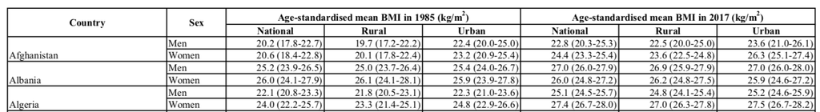

This looks the same as the begining… how about the end?

```r
cat(rural_urban[10])  # what about dplyr glimpse???
```

```
##                                                                                                             2                                                                  2
##                                                                    Age-standardised mean BMI in 1985 (kg/m )                           Age-standardised mean BMI in 2017 (kg/m )
##               Country                         Sex
##                                                               National               Rural                 Urban                  National               Rural                Urban
##                                         Men                   20.0 (18.6-21.4)      19.6 (18.1-21.1)      20.7 (19.2-22.0)        22.2 (21.6-22.9)      21.7 (21.0-22.4)     23.0 (22.3-23.7)
## Zambia                                  Women                 21.4 (20.3-22.6)      20.7 (19.5-21.9)      22.5 (21.3-23.7)        23.9 (23.3-24.5)      22.7 (22.1-23.3)     25.5 (24.9-26.2)
##                                         Men                   21.2 (20.2-22.3)      20.9 (19.8-22.1)      22.1 (21.1-23.1)        22.3 (21.7-22.9)      21.9 (21.2-22.5)     23.3 (22.6-23.9)
## Zimbabwe                                Women                 24.6 (23.5-25.9)      24.0 (22.8-25.4)      26.5 (25.3-27.8)        25.3 (24.6-26.1)      24.5 (23.7-25.3)     27.1 (26.2-27.9)
## *The entire population live in areas classified as urban (Bermuda, Hong Kong (from 1992 onwards), Nauru and Singapore) or rural (Tokelau).
## Numbers in parentheses show 95% credible intervals.
##                                                                                                  60
```

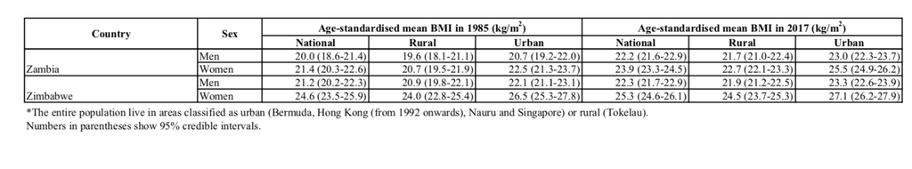

Great! Our rural_urban object looks like it contains the entire Supplementary 3 table, as both the beginning and the end include the data we expected.

###Wrangling

At this point we have large strings now for each page of the table, but this is not very convenient to work with. Now we will wrangle the data into a more usable form. Ideally we would like our data to be in some sort of tabular form.

First it would be useful to separate each page into lines.

```r
library(readr)
rural_urban <-read_lines(rural_urban)
str(rural_urban) # now we have 461 lines
```

```
##  chr [1:461] "                                                                          2                                    "| __truncated__ ...
```

```r
rural_urban[6] # we can see that line 6 shows the data for females in Afghanistan
```

```
## [1] "Afghanistan          Women   20.6 (18.4-22.8)      20.1 (17.8-22.4)     23.2 (20.9-25.4) 24.4 (23.3-25.4)      23.6 (22.5-24.8)     26.3 (25.1-27.4)"
```

We also have a lot of whitespace… let’s get rid of the excess white spaces.

```r
library(tidyverse)
rural_urban<-str_squish(rural_urban)
head(rural_urban)
```

```
## [1] "2 2"
## [2] "Age-standardised mean BMI in 1985 (kg/m ) Age-standardised mean BMI in 2017 (kg/m )"
## [3] "Country Sex"
## [4] "National Rural Urban National Rural Urban"
## [5] "Men 20.2 (17.8-22.7) 19.7 (17.2-22.2) 22.4 (20.0-25.0) 22.8 (20.3-25.3) 22.5 (20.0-25.0) 23.6 (21.0-26.1)"
## [6] "Afghanistan Women 20.6 (18.4-22.8) 20.1 (17.8-22.4) 23.2 (20.9-25.4) 24.4 (23.3-25.4) 23.6 (22.5-24.8) 26.3 (25.1-27.4)"
```

Now it is much easier to see the data.

If we look at the end of the first page of the table and the start of the second we can see that the header information is repeated, as well as a line with the page number and an empty line, and a line that says “2 2”.

```r
rural_urban[44:56]
```

```
##  [1] "Benin Women 20.6 (19.1-22.0) 20.1 (18.5-21.6) 21.8 (20.3-23.3) 24.3 (23.5-25.0) 23.2 (22.5-24.0) 25.5 (24.7-26.3)"
##  [2] "Men 24.3 (21.8-26.8) na* 24.3 (21.8-26.8) 26.7 (24.3-29.2) na* 26.7 (24.3-29.2)"
##  [3] "Bermuda Women 25.4 (22.2-28.6) na* 25.4 (22.2-28.6) 28.5 (25.3-31.6) na* 28.5 (25.3-31.6)"
##  [4] "Men 20.6 (19.1-22.1) 20.3 (18.7-21.8) 23.1 (21.5-24.6) 23.5 (22.8-24.3) 23.1 (22.2-23.9) 24.2 (23.3-25.2)"
##  [5] "Bhutan Women 20.7 (18.4-22.9) 20.3 (18.0-22.6) 23.0 (20.8-25.3) 24.6 (23.7-25.5) 23.8 (22.7-24.9) 25.9 (24.7-27.0)"
##  [6] "51"
##  [7] ""
##  [8] "2 2"
##  [9] "Age-standardised mean BMI in 1985 (kg/m ) Age-standardised mean BMI in 2017 (kg/m )"
## [10] "Country Sex"
## [11] "National Rural Urban National Rural Urban"
## [12] "Men 23.3 (21.0-25.5) 22.9 (20.6-25.2) 23.6 (21.3-25.9) 26.1 (23.9-28.4) 25.3 (23.1-27.5) 26.5 (24.2-28.8)"
## [13] "Bolivia Women 23.8 (22.3-25.3) 23.0 (21.4-24.5) 24.6 (23.1-26.1) 27.9 (26.5-29.3) 27.0 (25.6-28.5) 28.3 (26.8-29.7)"
```

Although the header was necessary on all of the pages of the pdf version of the table, we only need that information once in our data.. so we will remove all but the first instance of this information.

First, let’s save the header information that we would want to reference to make a single line header in the future:

```r
header <- rural_urban[1:4]
header
```

```
## [1] "2 2"
## [2] "Age-standardised mean BMI in 1985 (kg/m ) Age-standardised mean BMI in 2017 (kg/m )"
## [3] "Country Sex"
## [4] "National Rural Urban National Rural Urban"
```

Now, let’s remove all the header information and the page number lines from the rural_urban object. One way to do this is to find all lines that include either “women” or “men” and only keep this data.

```r
grep("Women|Men", rural_urban)
```

```
##   [1]   5   6   7   8   9  10  11  12  13  14  15  16  17  18  19  20  21
##  [18]  22  23  24  25  26  27  28  29  30  31  32  33  34  35  36  37  38
##  [35]  39  40  41  42  43  44  45  46  47  48  55  56  57  58  59  60  61
##  [52]  62  63  64  65  66  67  68  69  70  71  72  73  74  75  76  77  78
##  [69]  79  80  81  82  83  84  85  86  87  88  89  90  91  92  93  94  95
##  [86]  96  97  98 105 106 107 108 109 110 111 112 113 114 115 116 117 118
## [103] 119 120 121 122 123 124 125 126 127 128 129 130 131 132 133 134 135
## [120] 136 137 138 139 140 141 142 143 144 145 146 147 148 155 156 157 158
## [137] 159 160 161 162 163 164 165 166 167 168 169 170 171 172 173 174 175
## [154] 176 177 178 179 180 181 182 183 184 185 186 187 188 189 190 191 192
## [171] 193 194 195 196 197 198 205 206 207 208 209 210 211 212 213 214 215
## [188] 216 217 218 219 220 221 222 223 224 225 226 227 228 229 230 231 232
## [205] 233 234 235 236 237 238 239 240 241 242 243 244 245 246 247 248 255
## [222] 256 257 258 259 260 261 262 263 264 265 266 267 268 269 270 271 272
## [239] 273 274 275 276 277 278 279 280 281 282 283 284 285 286 287 288 289
## [256] 290 291 292 293 294 295 296 297 298 305 306 307 308 309 310 311 312
## [273] 313 314 315 316 317 318 319 320 321 322 323 324 325 326 327 328 329
## [290] 330 331 332 333 334 335 336 337 338 339 340 341 342 343 344 345 346
## [307] 347 348 355 356 357 358 359 360 361 362 363 364 365 366 367 368 369
## [324] 370 371 372 373 374 375 376 377 378 379 380 381 382 383 384 385 386
## [341] 387 388 389 390 391 392 393 394 395 396 397 398 405 406 407 408 409
## [358] 410 411 412 413 414 415 416 417 418 419 420 421 422 423 424 425 426
## [375] 427 428 429 430 431 432 433 434 435 436 437 438 439 440 441 442 443
## [392] 444 445 446 447 448 455 456 457 458
```

Ok, so this looks correct. This includes most lines but there are gaps where are header is located.

```r
rural_urban <- rural_urban[grep(pattern ="Women|Men", rural_urban)]
```

We can check our data now using either head() or glimpse().

```r
library(dplyr)
glimpse(rural_urban)
```

```
##  chr [1:400] "Men 20.2 (17.8-22.7) 19.7 (17.2-22.2) 22.4 (20.0-25.0) 22.8 (20.3-25.3) 22.5 (20.0-25.0) 23.6 (21.0-26.1)" ...
```

```r
head(rural_urban)
```

```
## [1] "Men 20.2 (17.8-22.7) 19.7 (17.2-22.2) 22.4 (20.0-25.0) 22.8 (20.3-25.3) 22.5 (20.0-25.0) 23.6 (21.0-26.1)"
## [2] "Afghanistan Women 20.6 (18.4-22.8) 20.1 (17.8-22.4) 23.2 (20.9-25.4) 24.4 (23.3-25.4) 23.6 (22.5-24.8) 26.3 (25.1-27.4)"
## [3] "Men 25.2 (23.9-26.5) 25.0 (23.7-26.4) 25.4 (24.0-26.7) 27.0 (26.0-27.9) 26.9 (25.9-27.9) 27.0 (26.0-28.0)"
## [4] "Albania Women 26.0 (24.1-27.9) 26.1 (24.1-28.1) 25.9 (23.9-27.8) 26.0 (24.8-27.2) 26.2 (24.8-27.5) 25.9 (24.6-27.2)"
## [5] "Men 22.1 (20.8-23.3) 21.8 (20.5-23.1) 22.3 (21.0-23.6) 25.1 (24.5-25.7) 24.8 (24.1-25.4) 25.2 (24.6-25.9)"
## [6] "Algeria Women 24.0 (22.2-25.7) 23.3 (21.4-25.1) 24.8 (22.9-26.6) 27.4 (26.7-28.0) 27.0 (26.3-27.8) 27.5 (26.7-28.2)"
```

So the `head()` function shows us the first rows or lines of the data, while the `glimpse()` function provides us information about the total size of the object and shows us the first line or row.

Great! So now our data looks much better but we need to add back our header and we would like this to only be a single line to make it easy to transform our data into a table or table-like object.

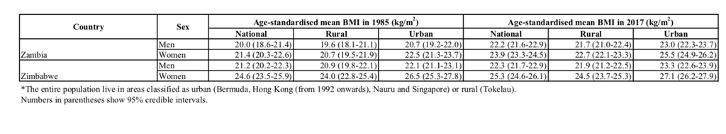

First let’s try splitting our headerless data into columns based on spaces:

```r
str_split(rural_urban, " ", simplify = TRUE)
```

```
##        [,1]           [,2]          [,3]          [,4]
##   [1,] "Men"          "20.2"        "(17.8-22.7)" "19.7"
##   [2,] "Afghanistan"  "Women"       "20.6"        "(18.4-22.8)"
##   [3,] "Men"          "25.2"        "(23.9-26.5)" "25.0"
##   [4,] "Albania"      "Women"       "26.0"        "(24.1-27.9)"
##   [5,] "Men"          "22.1"        "(20.8-23.3)" "21.8"
##   [6,] "Algeria"      "Women"       "24.0"        "(22.2-25.7)"
##   [7,] "Men"          "33.7"        "(32.7-34.7)" "32.6"
##   [8,] "American"     "Samoa"       "Women"       "34.3"
##   [9,] "Men"          "25.0"        "(22.5-27.4)" "25.3"
##  [10,] "Andorra"      "Women"       "25.2"        "(22.0-28.4)"
##  [11,] "Men"          "20.5"        "(17.9-23.1)" "20.2"
##  [12,] "Angola"       "Women"       "21.3"        "(18.0-24.6)"
##  [13,] "Men"          "23.6"        "(21.2-26.0)" "23.2"
##  [14,] "Antigua"      "and"         "Barbuda"     "Women"
```

[output cut: 1990 more lines]

This almost worked, but unfortunately country names that have spaces will be a problem. We can see that American Samoa has been divided into two columns and all subsequent columns are shifted.

So now let’s try to extract the country information, by separating the country information from the sex information when the sex is female. Sex always starts with either a capital “W” if the gender is female. We need to use a space before the “W” otherwise we will split some of the country names if the names starts with “W”. Here we will also introduce the concept of piping, which uses the `%>%`. This is really useful when we have multiple steps, which we will show soon.

```r
# Women <-rural_urban[grep(pattern ="Women", rural_urban)]
# country_split <-Women %>%
#   strsplit(split= " W") %>%
#   unlist()
Women <- stringr::str_subset(string = rural_urban, pattern = "Women") # First let's subset the data to only the lines that contain "Women"

country_split <-Women %>%
  stringr::str_split(pattern= " W") %>%
  unlist()

# country_split1 <-rural_urban %>%
#   strsplit(split= " W", " M") %>%
#   unlist()
#this is equivalent:
# library(stringr)
# country_split2 <-rural_urban %>%
#   stringr::str_split(pattern= " W| M") %>%
#   unlist() # this function will collapse the lists that are created when we use str_split()
#

head(country_split)
```

```
## [1] "Afghanistan"
## [2] "omen 20.6 (18.4-22.8) 20.1 (17.8-22.4) 23.2 (20.9-25.4) 24.4 (23.3-25.4) 23.6 (22.5-24.8) 26.3 (25.1-27.4)"
## [3] "Albania"
## [4] "omen 26.0 (24.1-27.9) 26.1 (24.1-28.1) 25.9 (23.9-27.8) 26.0 (24.8-27.2) 26.2 (24.8-27.5) 25.9 (24.6-27.2)"
## [5] "Algeria"
## [6] "omen 24.0 (22.2-25.7) 23.3 (21.4-25.1) 24.8 (22.9-26.6) 27.4 (26.7-28.0) 27.0 (26.3-27.8) 27.5 (26.7-28.2)"
```

```r
# this is equivalent to:
#country_split <-str_split(rural_urban, "W|M")
#country_split <-unlist(country_split)
```

Now we can see that Country is always the odd rows and the rest of the data is the rest of the rows

```r
country <-data.frame(country_split) %>%
  dplyr::filter(row_number() %% 2 == 1)
country
```

```
##                        country_split
## 1                        Afghanistan
## 2                            Albania
## 3                            Algeria
## 4                     American Samoa
## 5                            Andorra
## 6                             Angola
## 7                Antigua and Barbuda
## 8                          Argentina
## 9                            Armenia
## 10                         Australia
## 11                           Austria
## 12                        Azerbaijan
## 13                           Bahamas
## 14                           Bahrain
```

[output cut: 186 more lines]

```r
Women_BMI <-data.frame(country_split) %>%
  dplyr::filter(row_number() %% 2 == 0)
```

Great! Now we have a list of the countries that can be used for both the male and female data.

Let’s add the “W” back to our Women data:

```r
glimpse(Women)
```

```
##  chr [1:200] "Afghanistan Women 20.6 (18.4-22.8) 20.1 (17.8-22.4) 23.2 (20.9-25.4) 24.4 (23.3-25.4) 23.6 (22.5-24.8) 26.3 (25.1-27.4)" ...
```

```r
Women<-Women_BMI %>%
mutate(country_split =stringr::str_replace_all(string =country_split, pattern ="omen", replacement = "Women"))
head(Women$country_split)
```

```
## [1] "Women 20.6 (18.4-22.8) 20.1 (17.8-22.4) 23.2 (20.9-25.4) 24.4 (23.3-25.4) 23.6 (22.5-24.8) 26.3 (25.1-27.4)"
## [2] "Women 26.0 (24.1-27.9) 26.1 (24.1-28.1) 25.9 (23.9-27.8) 26.0 (24.8-27.2) 26.2 (24.8-27.5) 25.9 (24.6-27.2)"
## [3] "Women 24.0 (22.2-25.7) 23.3 (21.4-25.1) 24.8 (22.9-26.6) 27.4 (26.7-28.0) 27.0 (26.3-27.8) 27.5 (26.7-28.2)"
## [4] "Women 34.3 (33.1-35.6) 34.1 (33.0-35.2) 34.4 (33.0-35.8) 35.3 (33.7-36.9) 35.0 (33.1-36.9) 35.4 (33.7-37.1)"
## [5] "Women 25.2 (22.0-28.4) 25.4 (22.2-28.7) 25.2 (22.0-28.4) 25.3 (22.1-28.6) 25.2 (21.9-28.5) 25.3 (22.1-28.6)"
## [6] "Women 21.3 (18.0-24.6) 20.9 (17.6-24.3) 22.7 (19.3-26.0) 24.4 (21.2-27.7) 23.3 (20.0-26.7) 25.7 (22.4-29.1)"
```

It’s always a good idea to check that your data objects are the size you expect when wrangling.

```r
dim(Women)
```

```
## [1] 200   1
```

Great! There are 200 rows like we expected.

Let’s grab the male data:

```r
# remember our rural_urban object contains male data for the odd rows

Men <-data.frame(rural_urban) %>%
  dplyr::filter(row_number() %% 2 == 1)
head(Men$rural_urban)
```

```
## [1] Men 20.2 (17.8-22.7) 19.7 (17.2-22.2) 22.4 (20.0-25.0) 22.8 (20.3-25.3) 22.5 (20.0-25.0) 23.6 (21.0-26.1)
## [2] Men 25.2 (23.9-26.5) 25.0 (23.7-26.4) 25.4 (24.0-26.7) 27.0 (26.0-27.9) 26.9 (25.9-27.9) 27.0 (26.0-28.0)
## [3] Men 22.1 (20.8-23.3) 21.8 (20.5-23.1) 22.3 (21.0-23.6) 25.1 (24.5-25.7) 24.8 (24.1-25.4) 25.2 (24.6-25.9)
## [4] Men 33.7 (32.7-34.7) 32.6 (31.7-33.5) 34.0 (32.9-35.1) 34.3 (33.0-35.6) 34.6 (33.1-35.9) 34.2 (32.9-35.6)
## [5] Men 25.0 (22.5-27.4) 25.3 (22.8-27.7) 25.0 (22.5-27.4) 26.8 (24.4-29.2) 26.8 (24.3-29.2) 26.8 (24.3-29.3)
## [6] Men 20.5 (17.9-23.1) 20.2 (17.6-22.9) 21.4 (18.8-24.0) 22.6 (20.0-25.1) 22.0 (19.4-24.6) 23.2 (20.6-25.9)
## 400 Levels: Afghanistan Women 20.6 (18.4-22.8) 20.1 (17.8-22.4) 23.2 (20.9-25.4) 24.4 (23.3-25.4) 23.6 (22.5-24.8) 26.3 (25.1-27.4) ...
```

```r
dim(Men) # again let's make sure we have the correct number of rows for our final "Men" data object
```

```
## [1] 200   1
```

So close! Notice that there are `na*` values that have shifted the suqsequent values within the columns because typically there is a space between the BMI and the credible intervals. Here we can see this data in our original pdf:

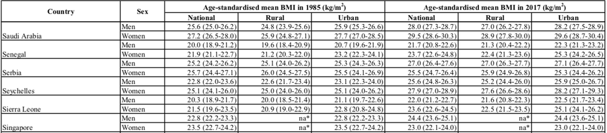

We need to repace our `na*` values with something that includes a space so that when we separate our data by space we will have two values instead of one when we have an `na*`. Therefore, `na* na*` should work.

```r
class(Men$rural_urban)# In order to use the functions within the stringr package, our Men data needs to be of character class
```

```
## [1] "factor"
```

```r
Men<-as.character(Men$rural_urban) # This function allows us to change the factor data within Men$rural_urban to the character class and we are changing the structure so that the data is directly just called Men and not within a vector called rural_urban
Men<-stringr::str_replace_all(string = Men, pattern = "na\\*", replacement = "na\\* na\\*") # the \\ are necessary because the * is a special character that would typically indicate that any possible value, but here we actually want a `*` instead, thus the double backslash does that for us.
# Here we are replacing all occurences of the na* values (thus str_replace_all instead of str_replace) that occur in the strings within Men with na* na*.
#To check that this worked...
Men[20:30]
```

```
##  [1] "Men 20.7 (19.4-22.1) 20.3 (18.9-21.7) 21.7 (20.3-23.1) 22.7 (22.0-23.3) 22.1 (21.3-22.8) 23.4 (22.7-24.1)"
##  [2] "Men 24.3 (21.8-26.8) na* na* 24.3 (21.8-26.8) 26.7 (24.3-29.2) na* na* 26.7 (24.3-29.2)"
##  [3] "Men 20.6 (19.1-22.1) 20.3 (18.7-21.8) 23.1 (21.5-24.6) 23.5 (22.8-24.3) 23.1 (22.2-23.9) 24.2 (23.3-25.2)"
##  [4] "Men 23.3 (21.0-25.5) 22.9 (20.6-25.2) 23.6 (21.3-25.9) 26.1 (23.9-28.4) 25.3 (23.1-27.5) 26.5 (24.2-28.8)"
##  [5] "Men 24.9 (23.5-26.2) 24.8 (23.4-26.2) 25.0 (23.6-26.4) 26.8 (25.7-27.8) 26.7 (25.7-27.8) 26.8 (25.7-27.9)"
##  [6] "Men 20.6 (19.2-22.0) 20.3 (18.8-21.7) 21.4 (20.0-22.9) 22.6 (21.9-23.4) 21.9 (20.9-22.8) 23.2 (22.3-24.0)"
##  [7] "Men 23.3 (22.5-24.0) 22.2 (21.4-23.0) 23.7 (22.9-24.5) 26.2 (25.7-26.7) 25.0 (24.3-25.6) 26.4 (25.9-26.9)"
##  [8] "Men 24.0 (22.5-25.4) 23.7 (22.1-25.1) 24.2 (22.7-25.7) 27.1 (26.4-27.7) 26.6 (26.0-27.3) 27.2 (26.5-27.9)"
##  [9] "Men 25.0 (23.8-26.4) 24.9 (23.5-26.4) 25.1 (23.8-26.5) 27.0 (25.8-28.1) 27.0 (25.7-28.3) 27.0 (25.7-28.2)"
## [10] "Men 20.2 (18.8-21.5) 20.0 (18.6-21.4) 21.4 (19.9-22.9) 22.2 (21.4-23.0) 21.8 (21.0-22.6) 23.1 (22.1-24.1)"
## [11] "Men 20.2 (17.7-22.6) 20.1 (17.6-22.5) 21.2 (18.7-23.6) 22.1 (19.8-24.5) 22.0 (19.6-24.3) 23.2 (20.8-25.6)"
```

```r
#YAY!


# Now for the Women data object
class(Women$country_split)# the female data is already in character form
```

```
## [1] "character"
```

```r
Women<-stringr::str_replace_all(string = Women$country_split, pattern = "na\\*", replacement = "na\\* na\\*")
Women[20:30]
```

```
##  [1] "Women 20.6 (19.1-22.0) 20.1 (18.5-21.6) 21.8 (20.3-23.3) 24.3 (23.5-25.0) 23.2 (22.5-24.0) 25.5 (24.7-26.3)"
##  [2] "Women 25.4 (22.2-28.6) na* na* 25.4 (22.2-28.6) 28.5 (25.3-31.6) na* na* 28.5 (25.3-31.6)"
##  [3] "Women 20.7 (18.4-22.9) 20.3 (18.0-22.6) 23.0 (20.8-25.3) 24.6 (23.7-25.5) 23.8 (22.7-24.9) 25.9 (24.7-27.0)"
##  [4] "Women 23.8 (22.3-25.3) 23.0 (21.4-24.5) 24.6 (23.1-26.1) 27.9 (26.5-29.3) 27.0 (25.6-28.5) 28.3 (26.8-29.7)"
##  [5] "Women 25.5 (23.5-27.4) 25.7 (23.7-27.7) 25.1 (23.1-27.0) 25.7 (24.4-27.1) 26.0 (24.6-27.5) 25.3 (23.9-26.8)"
##  [6] "Women 24.2 (22.2-26.2) 23.7 (21.5-25.8) 25.6 (23.5-27.7) 26.2 (25.3-27.1) 25.0 (23.8-26.2) 27.0 (26.0-28.2)"
##  [7] "Women 24.0 (23.2-25.0) 23.1 (22.1-24.1) 24.4 (23.5-25.4) 26.9 (26.2-27.5) 26.4 (25.7-27.2) 26.9 (26.3-27.6)"
##  [8] "Women 23.6 (21.4-25.6) 22.9 (20.7-25.0) 24.0 (21.8-26.1) 27.4 (26.6-28.1) 27.0 (26.1-27.8) 27.5 (26.7-28.2)"
##  [9] "Women 25.2 (23.4-27.1) 25.5 (23.4-27.6) 25.0 (23.1-26.9) 25.6 (24.1-27.1) 26.0 (24.2-27.8) 25.5 (23.9-27.1)"
## [10] "Women 19.9 (18.7-21.2) 19.6 (18.4-20.9) 22.0 (20.7-23.3) 22.2 (21.4-23.1) 21.1 (20.2-22.0) 24.7 (23.7-25.7)"
## [11] "Women 19.6 (17.5-21.7) 19.5 (17.4-21.6) 21.7 (19.5-23.8) 21.1 (20.3-22.0) 20.7 (19.8-21.6) 24.0 (23.0-24.9)"
```

Great, now we can split our data by spaces.

```r
#Men<-as_tibble(str_split(Men$rural_urban, " ", simplify = TRUE))# note here we need to use the column of Men that has the data
#Men
```

```r
Men <-as_tibble(str_split(Men, " ", simplify = TRUE))# note here we need to use the column of Women that has the data
head(Men)
```

```
## # A tibble: 6 x 13
##   V1    V2    V3     V4    V5     V6    V7    V8    V9    V10   V11   V12
##   <chr> <chr> <chr>  <chr> <chr>  <chr> <chr> <chr> <chr> <chr> <chr> <chr>
## 1 Men   20.2  (17.8… 19.7  (17.2… 22.4  (20.… 22.8  (20.… 22.5  (20.… 23.6
## 2 Men   25.2  (23.9… 25.0  (23.7… 25.4  (24.… 27.0  (26.… 26.9  (25.… 27.0
## 3 Men   22.1  (20.8… 21.8  (20.5… 22.3  (21.… 25.1  (24.… 24.8  (24.… 25.2
## 4 Men   33.7  (32.7… 32.6  (31.7… 34.0  (32.… 34.3  (33.… 34.6  (33.… 34.2
## 5 Men   25.0  (22.5… 25.3  (22.8… 25.0  (22.… 26.8  (24.… 26.8  (24.… 26.8
## 6 Men   20.5  (17.9… 20.2  (17.6… 21.4  (18.… 22.6  (20.… 22.0  (19.… 23.2
## # … with 1 more variable: V13 <chr>
```

```r
Women<-as_tibble(str_split(Women, " ", simplify = TRUE))# note here we need to use the column of Women that has the data
head(Women)
```

```
## # A tibble: 6 x 13
##   V1    V2    V3     V4    V5     V6    V7    V8    V9    V10   V11   V12
##   <chr> <chr> <chr>  <chr> <chr>  <chr> <chr> <chr> <chr> <chr> <chr> <chr>
## 1 Women 20.6  (18.4… 20.1  (17.8… 23.2  (20.… 24.4  (23.… 23.6  (22.… 26.3
## 2 Women 26.0  (24.1… 26.1  (24.1… 25.9  (23.… 26.0  (24.… 26.2  (24.… 25.9
## 3 Women 24.0  (22.2… 23.3  (21.4… 24.8  (22.… 27.4  (26.… 27.0  (26.… 27.5
## 4 Women 34.3  (33.1… 34.1  (33.0… 34.4  (33.… 35.3  (33.… 35.0  (33.… 35.4
## 5 Women 25.2  (22.0… 25.4  (22.2… 25.2  (22.… 25.3  (22.… 25.2  (21.… 25.3
## 6 Women 21.3  (18.0… 20.9  (17.6… 22.7  (19.… 24.4  (21.… 23.3  (20.… 25.7
## # … with 1 more variable: V13 <chr>
```

```r
Women[20:30,] # we can see that our na values look correct
```

```
## # A tibble: 11 x 13
##    V1    V2    V3     V4    V5    V6    V7    V8    V9    V10   V11   V12
##    <chr> <chr> <chr>  <chr> <chr> <chr> <chr> <chr> <chr> <chr> <chr> <chr>
##  1 Women 20.6  (19.1… 20.1  (18.… 21.8  (20.… 24.3  (23.… 23.2  (22.… 25.5
##  2 Women 25.4  (22.2… na*   na*   25.4  (22.… 28.5  (25.… na*   na*   28.5
##  3 Women 20.7  (18.4… 20.3  (18.… 23.0  (20.… 24.6  (23.… 23.8  (22.… 25.9
##  4 Women 23.8  (22.3… 23.0  (21.… 24.6  (23.… 27.9  (26.… 27.0  (25.… 28.3
##  5 Women 25.5  (23.5… 25.7  (23.… 25.1  (23.… 25.7  (24.… 26.0  (24.… 25.3
##  6 Women 24.2  (22.2… 23.7  (21.… 25.6  (23.… 26.2  (25.… 25.0  (23.… 27.0
##  7 Women 24.0  (23.2… 23.1  (22.… 24.4  (23.… 26.9  (26.… 26.4  (25.… 26.9
##  8 Women 23.6  (21.4… 22.9  (20.… 24.0  (21.… 27.4  (26.… 27.0  (26.… 27.5
##  9 Women 25.2  (23.4… 25.5  (23.… 25.0  (23.… 25.6  (24.… 26.0  (24.… 25.5
## 10 Women 19.9  (18.7… 19.6  (18.… 22.0  (20.… 22.2  (21.… 21.1  (20.… 24.7
## 11 Women 19.6  (17.5… 19.5  (17.… 21.7  (19.… 21.1  (20.… 20.7  (19.… 24.0
## # … with 1 more variable: V13 <chr>
```

We can see from our pdf and our object called header what the header was like. Let’s also make a new single line header, but let’s wait to add Country:

```r
#header
new_header <-c("Sex","National_BMI_1985", "National_BMI_1985_CI", "Rural_BMI_1985", "Rural_BMI_1985_CI", "Urban_BMI_1985", "Urban_BMI_1985_CI", "National_BMI_2017", "National_BMI_2017_CI","Rural_BMI_2017", "Rural_BMI_2017_CI", "Urban_BMI_2017", "Urban_BMI_2017_CI")
```

Let’s change the names of our columns of our tibble to this new header for our Men and Women data

```r
names(Women)<-new_header
names(Men)<-new_header
```

Now we will add our country data to both our Men and Women tibbles

```r
Women <- dplyr::bind_cols(country, Women)# this will add the country as a new column to the Women data object on the left
Men <- dplyr::bind_cols(country, Men) # this will add the country as a new column to the Men data object on the left
head(Women)
```

```
##    country_split   Sex National_BMI_1985 National_BMI_1985_CI
## 1    Afghanistan Women              20.6          (18.4-22.8)
## 2        Albania Women              26.0          (24.1-27.9)
## 3        Algeria Women              24.0          (22.2-25.7)
## 4 American Samoa Women              34.3          (33.1-35.6)
## 5        Andorra Women              25.2          (22.0-28.4)
## 6         Angola Women              21.3          (18.0-24.6)
##   Rural_BMI_1985 Rural_BMI_1985_CI Urban_BMI_1985 Urban_BMI_1985_CI
## 1           20.1       (17.8-22.4)           23.2       (20.9-25.4)
## 2           26.1       (24.1-28.1)           25.9       (23.9-27.8)
## 3           23.3       (21.4-25.1)           24.8       (22.9-26.6)
## 4           34.1       (33.0-35.2)           34.4       (33.0-35.8)
## 5           25.4       (22.2-28.7)           25.2       (22.0-28.4)
## 6           20.9       (17.6-24.3)           22.7       (19.3-26.0)
##   National_BMI_2017 National_BMI_2017_CI Rural_BMI_2017 Rural_BMI_2017_CI
## 1              24.4          (23.3-25.4)           23.6       (22.5-24.8)
## 2              26.0          (24.8-27.2)           26.2       (24.8-27.5)
## 3              27.4          (26.7-28.0)           27.0       (26.3-27.8)
## 4              35.3          (33.7-36.9)           35.0       (33.1-36.9)
## 5              25.3          (22.1-28.6)           25.2       (21.9-28.5)
## 6              24.4          (21.2-27.7)           23.3       (20.0-26.7)
##   Urban_BMI_2017 Urban_BMI_2017_CI
## 1           26.3       (25.1-27.4)
## 2           25.9       (24.6-27.2)
## 3           27.5       (26.7-28.2)
## 4           35.4       (33.7-37.1)
## 5           25.3       (22.1-28.6)
## 6           25.7       (22.4-29.1)
```

Here we will change the variable name of the country data to country, currently it is called country_split. Here we will also introduce the concept of the assignment pipe. In this case our pipe opperator looks like this `%<>%` . Using this fancier pipe requires another package, called magrittr. The other simpler pipe options from this package are loaded with tidyverse, but not this fancier version.

The `>` portion of the pipe still behaves like a normal pipe, while the `<` portion of the pipe makes an assignment to whatever the `<`is pointing to, just like when we use the typical assignment opperator `<-`.

```r
library(magrittr)
# Here we will just use the traditional assignment strategy
Women<-rename(Women, Country = country_split) # here we will rename the country_split variable to be called country

# Here we reassign Men using the pipe strategy
Men %<>%rename(Country = country_split) # here we will rename the country_split variable to to be called country and then reassign Men to the data object which has the country variable renamed
```

```r
BMI<-dplyr::full_join(x = Men, y = Women)
str(BMI)#let's check the size of our BMI data... it should have 400 rows (obs).
```

```
## 'data.frame':    400 obs. of  14 variables:
##  $ Country             : Factor w/ 400 levels "Afghanistan",..: 1 2 3 4 5 6 7 8 9 10 ...
##  $ Sex                 : chr  "Men" "Men" "Men" "Men" ...
##  $ National_BMI_1985   : chr  "20.2" "25.2" "22.1" "33.7" ...
##  $ National_BMI_1985_CI: chr  "(17.8-22.7)" "(23.9-26.5)" "(20.8-23.3)" "(32.7-34.7)" ...
##  $ Rural_BMI_1985      : chr  "19.7" "25.0" "21.8" "32.6" ...
##  $ Rural_BMI_1985_CI   : chr  "(17.2-22.2)" "(23.7-26.4)" "(20.5-23.1)" "(31.7-33.5)" ...
##  $ Urban_BMI_1985      : chr  "22.4" "25.4" "22.3" "34.0" ...
##  $ Urban_BMI_1985_CI   : chr  "(20.0-25.0)" "(24.0-26.7)" "(21.0-23.6)" "(32.9-35.1)" ...
##  $ National_BMI_2017   : chr  "22.8" "27.0" "25.1" "34.3" ...
##  $ National_BMI_2017_CI: chr  "(20.3-25.3)" "(26.0-27.9)" "(24.5-25.7)" "(33.0-35.6)" ...
##  $ Rural_BMI_2017      : chr  "22.5" "26.9" "24.8" "34.6" ...
##  $ Rural_BMI_2017_CI   : chr  "(20.0-25.0)" "(25.9-27.9)" "(24.1-25.4)" "(33.1-35.9)" ...
##  $ Urban_BMI_2017      : chr  "23.6" "27.0" "25.2" "34.2" ...
##  $ Urban_BMI_2017_CI   : chr  "(21.0-26.1)" "(26.0-28.0)" "(24.6-25.9)" "(32.9-35.6)" ...
```

Now Lets sort the data by country:

```r
BMI <-dplyr::arrange(BMI, Country)
head(BMI)
```

```
##       Country   Sex National_BMI_1985 National_BMI_1985_CI Rural_BMI_1985
## 1 Afghanistan   Men              20.2          (17.8-22.7)           19.7
## 2 Afghanistan Women              20.6          (18.4-22.8)           20.1
## 3     Albania   Men              25.2          (23.9-26.5)           25.0
## 4     Albania Women              26.0          (24.1-27.9)           26.1
## 5     Algeria   Men              22.1          (20.8-23.3)           21.8
## 6     Algeria Women              24.0          (22.2-25.7)           23.3
##   Rural_BMI_1985_CI Urban_BMI_1985 Urban_BMI_1985_CI National_BMI_2017
## 1       (17.2-22.2)           22.4       (20.0-25.0)              22.8
## 2       (17.8-22.4)           23.2       (20.9-25.4)              24.4
## 3       (23.7-26.4)           25.4       (24.0-26.7)              27.0
## 4       (24.1-28.1)           25.9       (23.9-27.8)              26.0
## 5       (20.5-23.1)           22.3       (21.0-23.6)              25.1
## 6       (21.4-25.1)           24.8       (22.9-26.6)              27.4
##   National_BMI_2017_CI Rural_BMI_2017 Rural_BMI_2017_CI Urban_BMI_2017
## 1          (20.3-25.3)           22.5       (20.0-25.0)           23.6
## 2          (23.3-25.4)           23.6       (22.5-24.8)           26.3
## 3          (26.0-27.9)           26.9       (25.9-27.9)           27.0
## 4          (24.8-27.2)           26.2       (24.8-27.5)           25.9
## 5          (24.5-25.7)           24.8       (24.1-25.4)           25.2
## 6          (26.7-28.0)           27.0       (26.3-27.8)           27.5
##   Urban_BMI_2017_CI
## 1       (21.0-26.1)
## 2       (25.1-27.4)
## 3       (26.0-28.0)
## 4       (24.6-27.2)
## 5       (24.6-25.9)
## 6       (26.7-28.2)
```

Our data is looking great! Now we might want to make sure that our observations for each variable look the way we want. In otherwords if we want to make plots about National BMI in 1985 then we would need our values to be numeric. Looking at our BMI data using `str()`, we can see the type of data for each of our variables listed just after variable name and the `:`. Looks like none of our BMI data is actually numeric. Let’s change that now.

```r
str(BMI)
```

```
## 'data.frame':    400 obs. of  14 variables:
##  $ Country             : Factor w/ 400 levels "Afghanistan",..: 1 1 2 2 3 3 4 4 5 5 ...
##  $ Sex                 : chr  "Men" "Women" "Men" "Women" ...
##  $ National_BMI_1985   : chr  "20.2" "20.6" "25.2" "26.0" ...
##  $ National_BMI_1985_CI: chr  "(17.8-22.7)" "(18.4-22.8)" "(23.9-26.5)" "(24.1-27.9)" ...
##  $ Rural_BMI_1985      : chr  "19.7" "20.1" "25.0" "26.1" ...
##  $ Rural_BMI_1985_CI   : chr  "(17.2-22.2)" "(17.8-22.4)" "(23.7-26.4)" "(24.1-28.1)" ...
##  $ Urban_BMI_1985      : chr  "22.4" "23.2" "25.4" "25.9" ...
##  $ Urban_BMI_1985_CI   : chr  "(20.0-25.0)" "(20.9-25.4)" "(24.0-26.7)" "(23.9-27.8)" ...
##  $ National_BMI_2017   : chr  "22.8" "24.4" "27.0" "26.0" ...
##  $ National_BMI_2017_CI: chr  "(20.3-25.3)" "(23.3-25.4)" "(26.0-27.9)" "(24.8-27.2)" ...
##  $ Rural_BMI_2017      : chr  "22.5" "23.6" "26.9" "26.2" ...
##  $ Rural_BMI_2017_CI   : chr  "(20.0-25.0)" "(22.5-24.8)" "(25.9-27.9)" "(24.8-27.5)" ...
##  $ Urban_BMI_2017      : chr  "23.6" "26.3" "27.0" "25.9" ...
##  $ Urban_BMI_2017_CI   : chr  "(21.0-26.1)" "(25.1-27.4)" "(26.0-28.0)" "(24.6-27.2)" ...
```

```r
BMI$National_BMI_1985%<>% as.numeric
BMI$Rural_BMI_1985%<>% as.numeric
BMI$Urban_BMI_1985%<>% as.numeric

BMI$National_BMI_2017%<>% as.numeric
BMI$Rural_BMI_2017%<>% as.numeric
BMI$Urban_BMI_2017%<>% as.numeric

str(BMI)# we can see now these variables show as "num" which stands for numeric
```

```
## 'data.frame':    400 obs. of  14 variables:
##  $ Country             : Factor w/ 400 levels "Afghanistan",..: 1 1 2 2 3 3 4 4 5 5 ...
##  $ Sex                 : chr  "Men" "Women" "Men" "Women" ...
##  $ National_BMI_1985   : num  20.2 20.6 25.2 26 22.1 24 33.7 34.3 25 25.2 ...
##  $ National_BMI_1985_CI: chr  "(17.8-22.7)" "(18.4-22.8)" "(23.9-26.5)" "(24.1-27.9)" ...
##  $ Rural_BMI_1985      : num  19.7 20.1 25 26.1 21.8 23.3 32.6 34.1 25.3 25.4 ...
##  $ Rural_BMI_1985_CI   : chr  "(17.2-22.2)" "(17.8-22.4)" "(23.7-26.4)" "(24.1-28.1)" ...
##  $ Urban_BMI_1985      : num  22.4 23.2 25.4 25.9 22.3 24.8 34 34.4 25 25.2 ...
##  $ Urban_BMI_1985_CI   : chr  "(20.0-25.0)" "(20.9-25.4)" "(24.0-26.7)" "(23.9-27.8)" ...
##  $ National_BMI_2017   : num  22.8 24.4 27 26 25.1 27.4 34.3 35.3 26.8 25.3 ...
##  $ National_BMI_2017_CI: chr  "(20.3-25.3)" "(23.3-25.4)" "(26.0-27.9)" "(24.8-27.2)" ...
##  $ Rural_BMI_2017      : num  22.5 23.6 26.9 26.2 24.8 27 34.6 35 26.8 25.2 ...
##  $ Rural_BMI_2017_CI   : chr  "(20.0-25.0)" "(22.5-24.8)" "(25.9-27.9)" "(24.8-27.5)" ...
##  $ Urban_BMI_2017      : num  23.6 26.3 27 25.9 25.2 27.5 34.2 35.4 26.8 25.3 ...
##  $ Urban_BMI_2017_CI   : chr  "(21.0-26.1)" "(25.1-27.4)" "(26.0-28.0)" "(24.6-27.2)" ...
```

```r
#We might want to just compare males and females or look at their data separately... since we already have this data let's also make these values numeric for these data objects
Women$National_BMI_1985%<>% as.numeric
Women$Rural_BMI_1985%<>% as.numeric
Women$Urban_BMI_1985%<>% as.numeric

Women$National_BMI_2017%<>% as.numeric
Women$Rural_BMI_2017%<>% as.numeric
Women$Urban_BMI_2017%<>% as.numeric

Men$National_BMI_1985%<>% as.numeric
Men$Rural_BMI_1985%<>% as.numeric
Men$Urban_BMI_1985%<>% as.numeric

Men$National_BMI_2017%<>% as.numeric
Men$Rural_BMI_2017%<>% as.numeric
Men$Urban_BMI_2017%<>% as.numeric
```

## Data Exploration

Now that our data is clean and in a format that we can work with, we can start to take a look at the data and how different groups might compare.

One of the first things that is useful to do with data is to plot the frequency of the different possible values. This is called a `distribution`. To do this we can use the `hist()` function to create a histogram.

If the data were what we call `normally distributed` then the distribution should be equally centered around the mean and would look something like this:

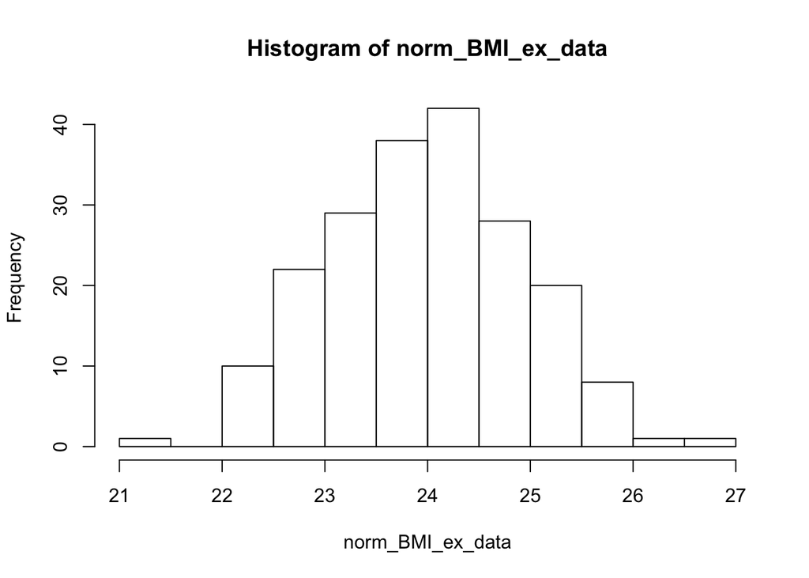

```r
norm_BMI_ex_data <- rnorm(n = 200, mean = 24) # this function allows us to make a vector of normaly distributed data centered around the mean of 24
hist(norm_BMI_ex_data)
```

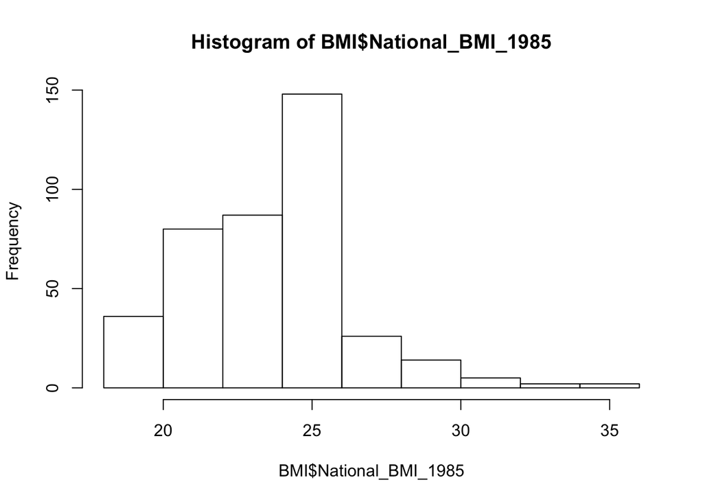

```r
hist(BMI$National_BMI_1985)
```

Ok so the data looks it might be slighty what we call `right skewed` because the tail of the distribution is longer on the right side.

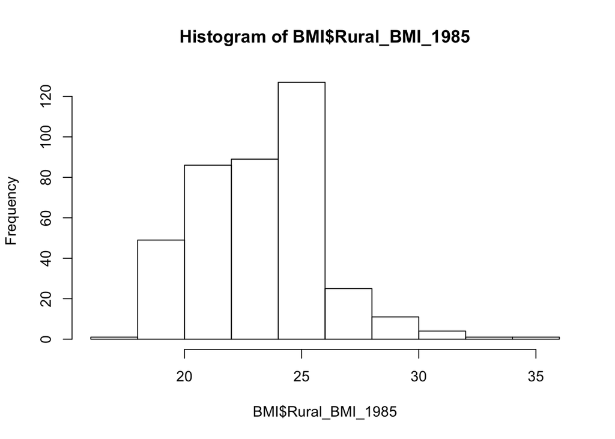

```r
hist(BMI$Rural_BMI_1985)
```

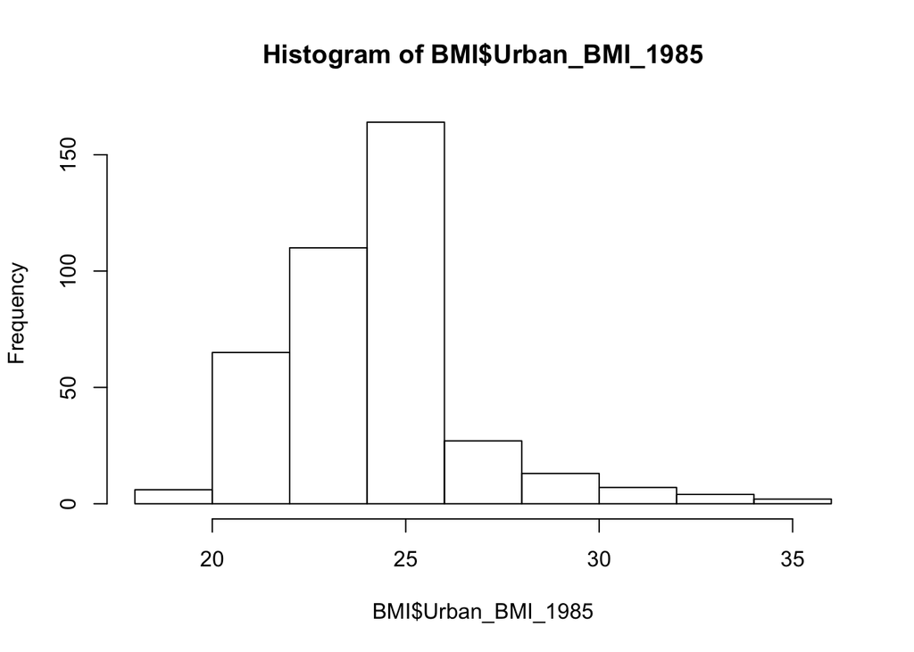

```r
hist(BMI$Urban_BMI_1985)
```

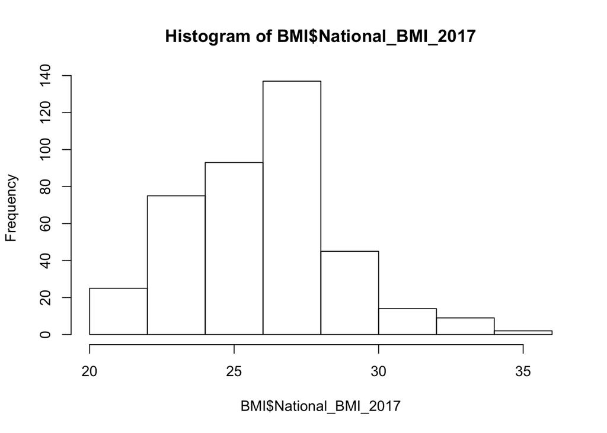

```r
hist(BMI$National_BMI_2017)
```

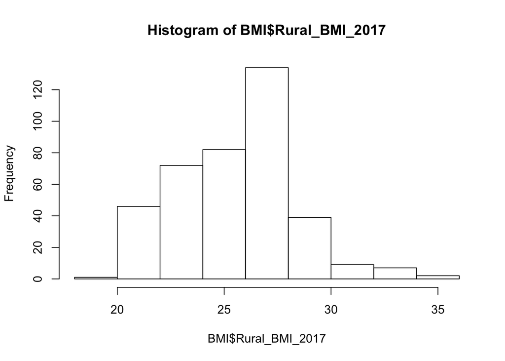

```r
hist(BMI$Rural_BMI_2017)
```

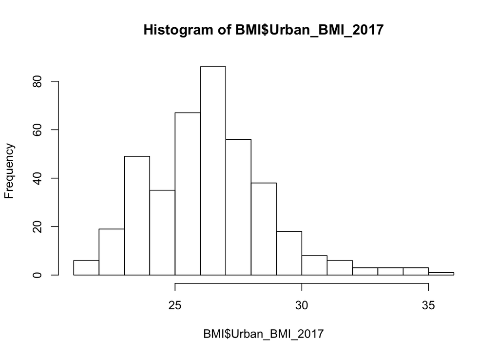

```r
hist(BMI$Urban_BMI_2017)
```

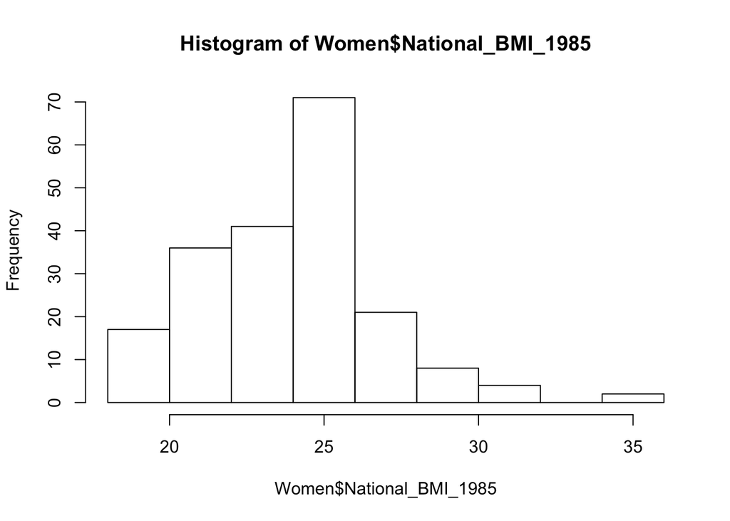

```r
hist(Women$National_BMI_1985)
```

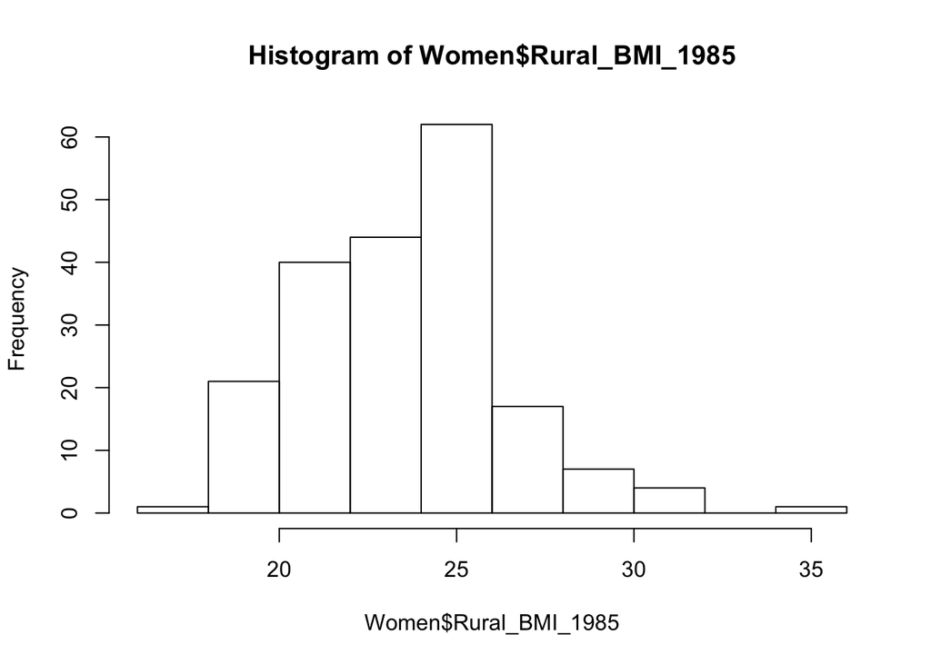

```r
hist(Women$Rural_BMI_1985)
```

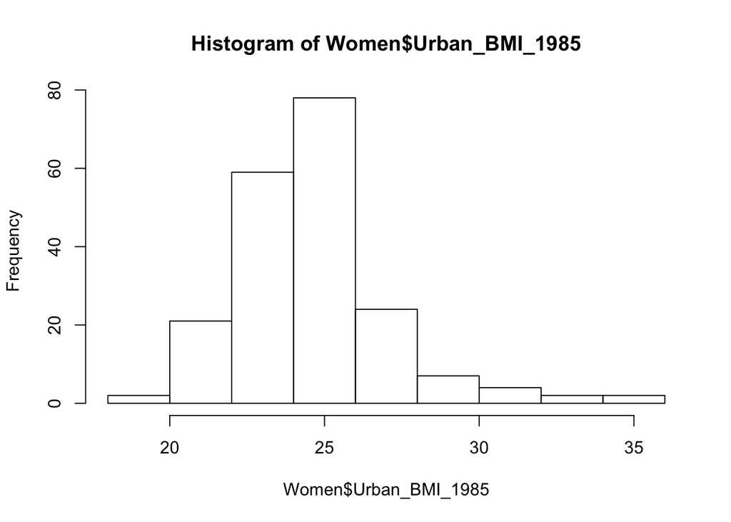

```r
hist(Women$Urban_BMI_1985)
```

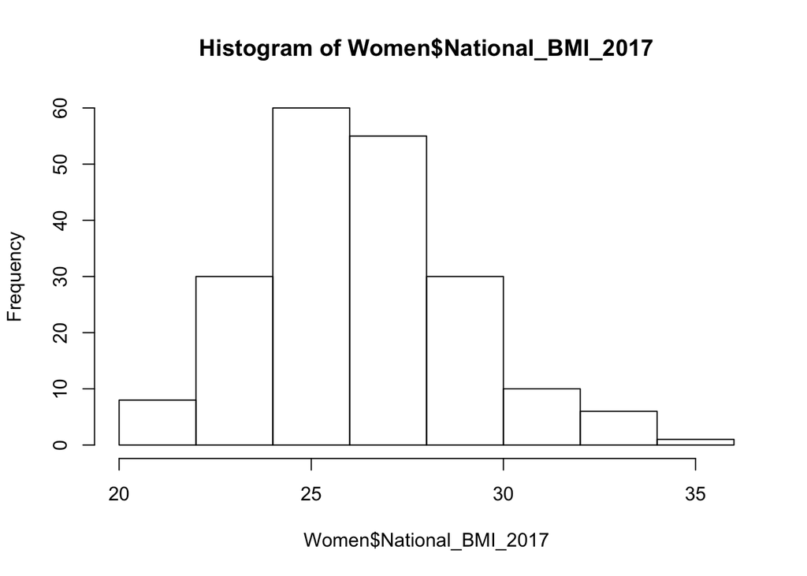

```r
hist(Women$National_BMI_2017)
```

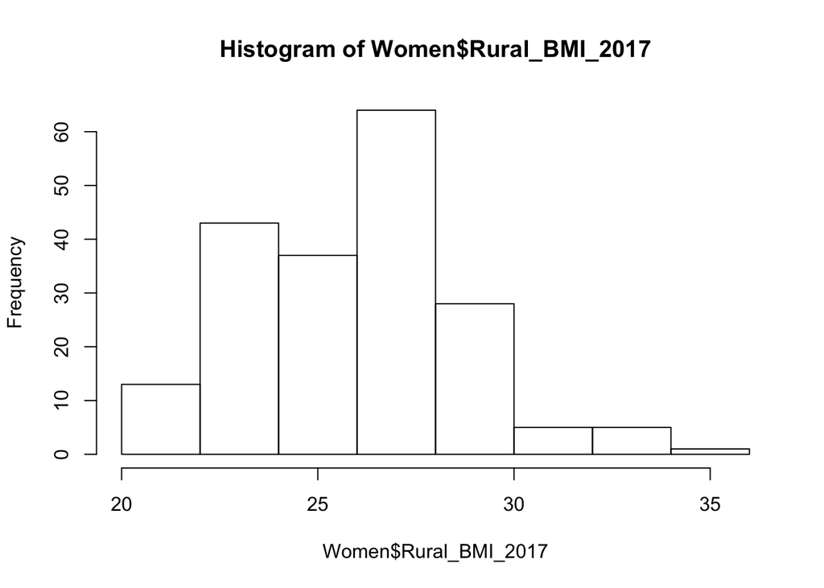

```r
hist(Women$Rural_BMI_2017)
```

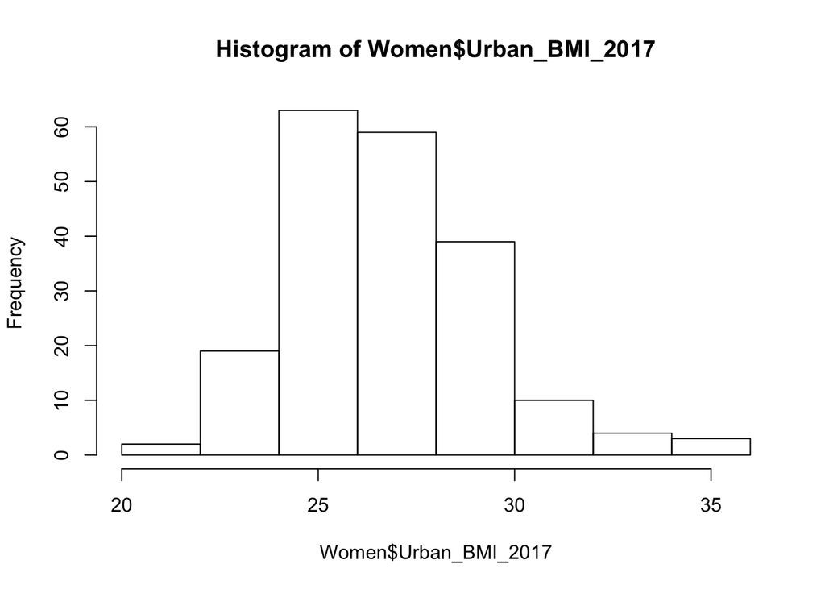

```r
hist(Women$Urban_BMI_2017)
```

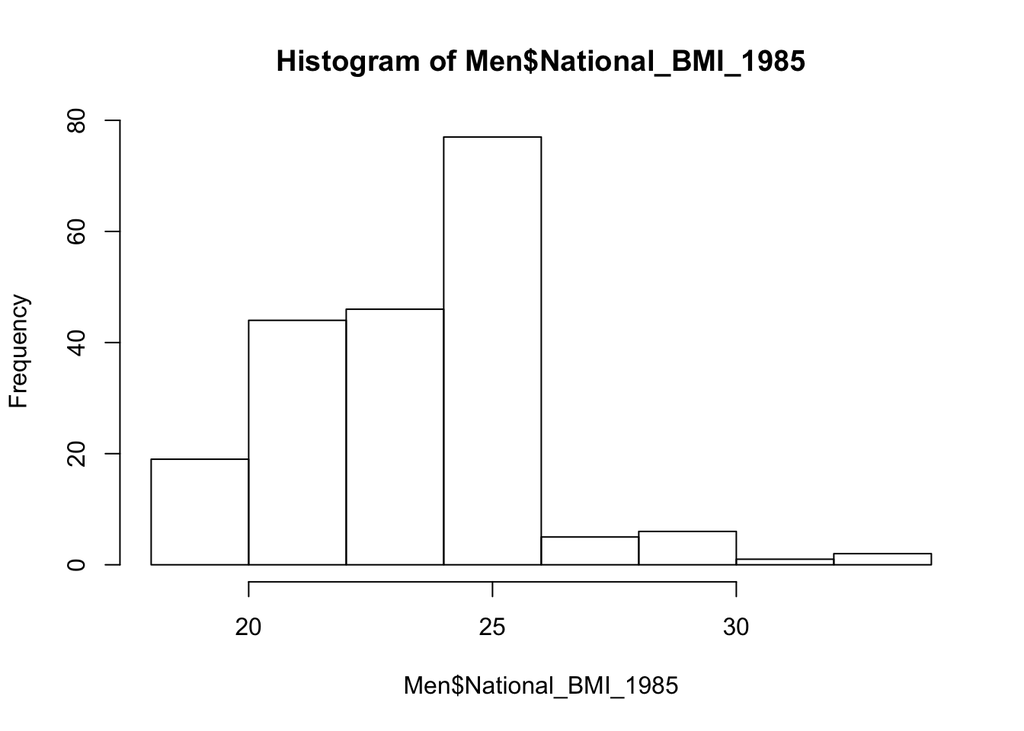

```r
hist(Men$National_BMI_1985)
```

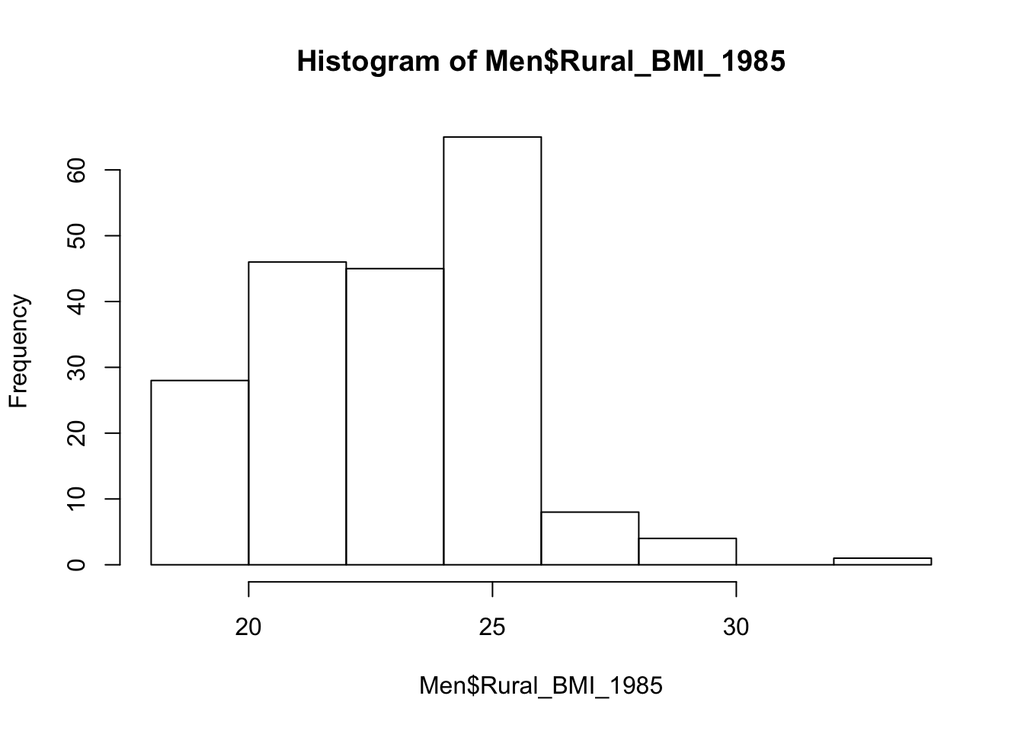

```r
hist(Men$Rural_BMI_1985)
```

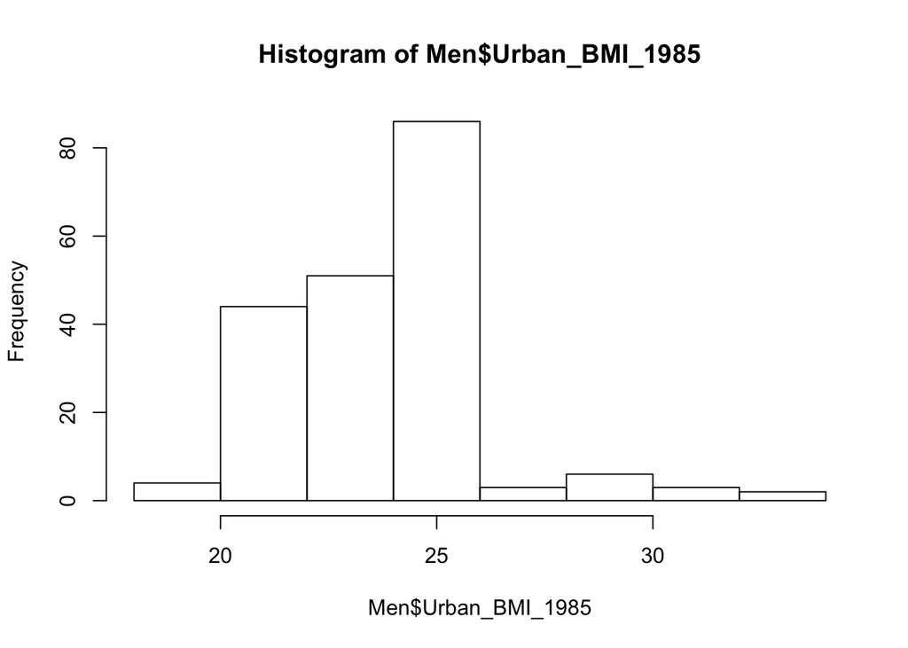

```r
hist(Men$Urban_BMI_1985)
```

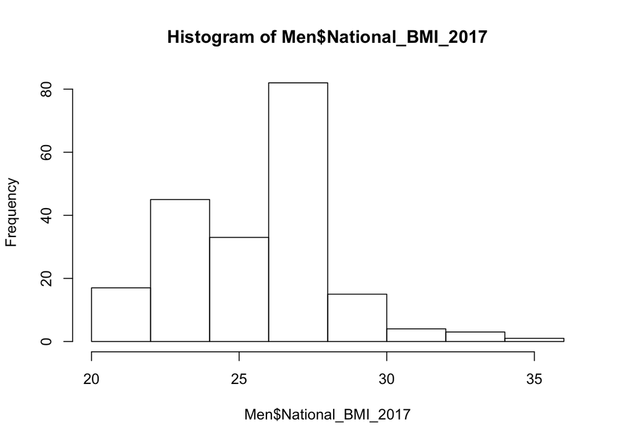

```r
hist(Men$National_BMI_2017)
```

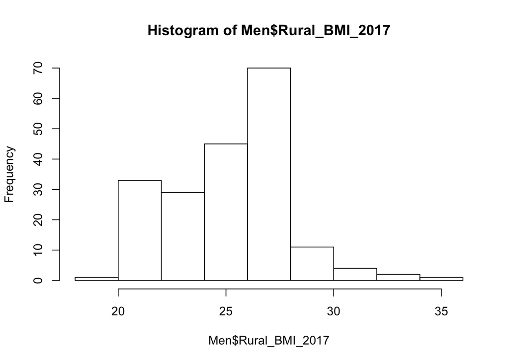

```r
hist(Men$Rural_BMI_2017)
```

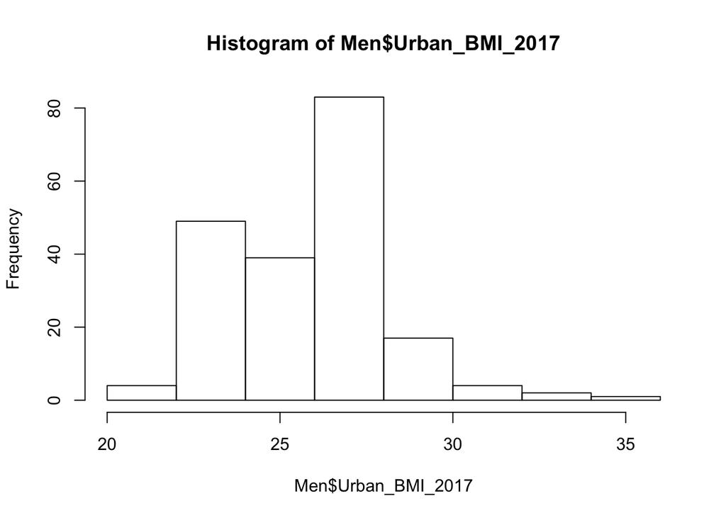

```r
hist(Men$Urban_BMI_2017)
```

Let’s use a method called qqplots to determine if the data is indeed normally distributed. This method allows us to test the fit of known thoretical distributions (like the normal distribution) with our oberved distribution.

Here is an example of a qqplot for the normally distributed data that we just created:

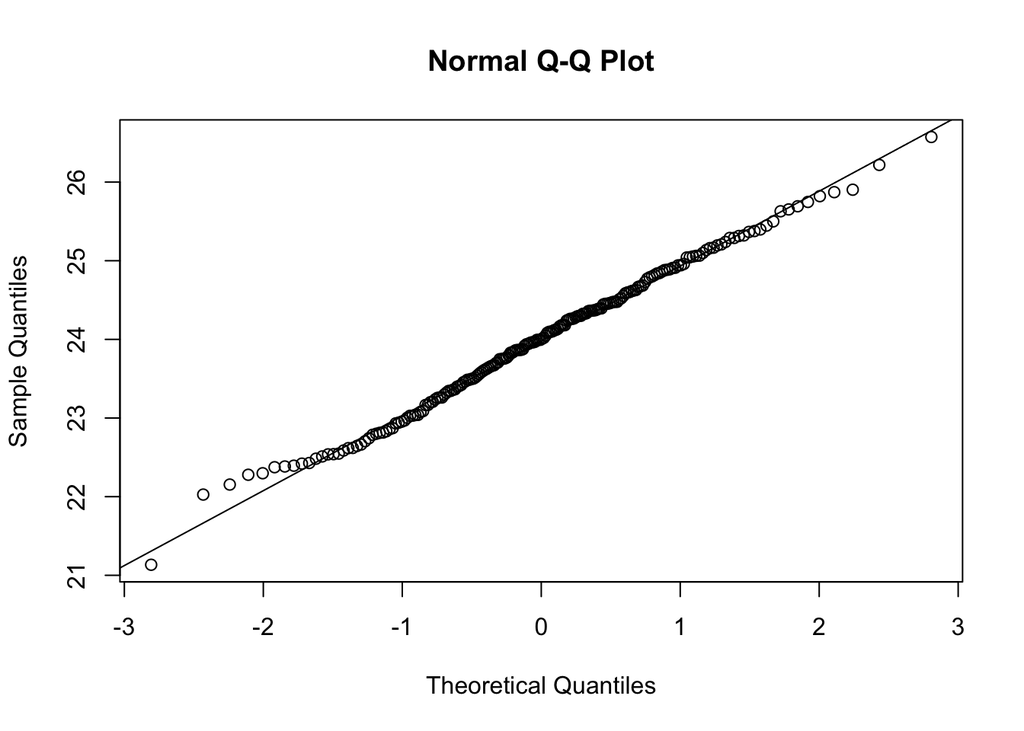

```r
qqnorm(norm_BMI_ex_data)
qqline(norm_BMI_ex_data)
```